# Gender Wage Gap in Swiss Labor Market

## Gender Wage Gap in Switzerland

- Persistent challenge in the Swiss labor market
- Analysis based on comprehensive labor market data
- Focus on structural determinants and potential solutions

## Some Lit Review on the topic

- gender wage gap in Switzerland is a well-documented phenomenon.
  - Rios-Rull and Zhang (2018) found that the wage gap in Switzerland is one of the highest in Europe.
  - According to the Swiss Federal Statistical Office (FSO), the unconditional gender wage gap is around 16%.

## Data Overview

- Sample of 1,647 Swiss workers
- Key variables:
  - Hourly wages (log-transformed)
  - Education (years)
  - Work experience
  - Job tenure
  - Occupational categories (ISCO)
  - Demographics (age, marital status, children)

## Descriptive Statistics

| Variable | Women | Men | Gap |
| --- | --- | --- | --- |
| Average hourly wage (CHF) | 28.7 | 34.2 | -16.1% |
| Years of education | 11.2 | 11.6 | -0.4 |
| Work experience | 12.1 | 14.3 | -2.2 |
| Job tenure | 6.9 | 8.9 | -2.0 |

## Raw Wage Gap Analysis

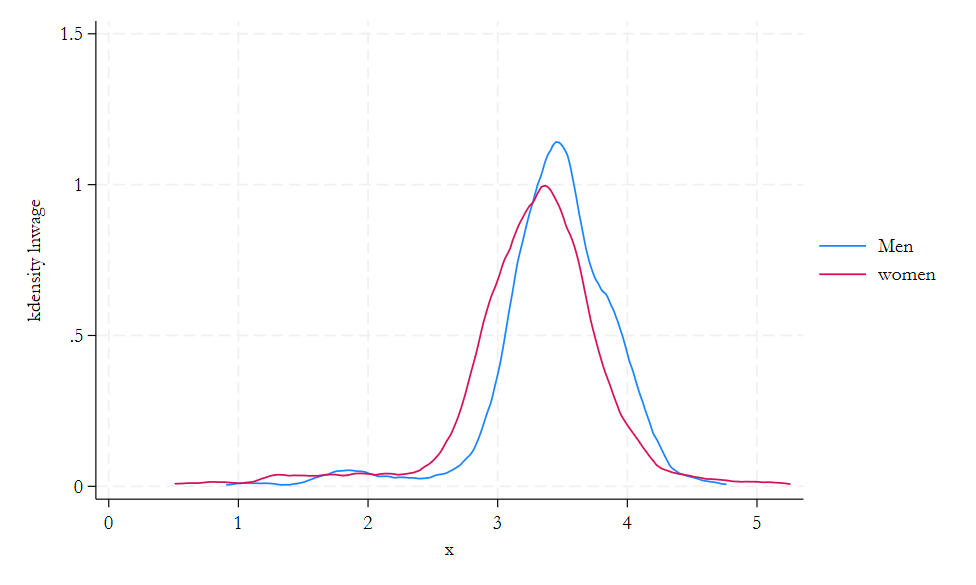

Wage Distribution by Gender

## Adjusted Wage Gap

| Model | Unadjusted Gap | Adjusted Gap | % Explained |
| --- | --- | --- | --- |
| Base | -16.1% | - | - |
| + Human Capital | -16.1% | -12.3% | 23.6% |
| + Job Characteristics | -16.1% | -9.7% | 39.8% |
| + Family Status | -16.1% | -8.4% | 47.8% |

## Occupational Segregation

- Women are overrepresented in:
  - Lower-paying occupations
  - Part-time positions
  - Service sector jobs
- Vertical segregation remains significant
- Glass ceiling effects persist

## Policy Implications

1. Transparent wage policies
2. Family-friendly work arrangements
3. Career development programs
4. Anti-discrimination measures
5. Early education initiatives

## Conclusion

- Wage gap in Switzerland is a complex issue
- Requires multi-faceted policy interventions
- Structural changes are necessary